# Biodiversity in National Parks

The investigation was conducted based on data provided by CodeCademy

In this researchwe will look at:

- distribution of species by category
- distribution of conservation_status by park_name
- distribution of conservation_status by category
- Amount of animals and plants in parks
- distribution of observations by specie
- the most and the least observed species in the parks

First import all necessary libraries

```python
import pandas as pd
import seaborn as sns
import numpy as np
from matplotlib import pyplot as plt
from pandas_profiling import ProfileReport
%matplotlib inline
```

## Data preparation

Read data from csv files

```python
observations = pd.read_csv('observations.csv')
species = pd.read_csv('species_info.csv')
print('\n', species[species.scientific_name == 'Abies bifolia'].to_string())
```

```
             category scientific_name               common_names conservation_status
4061  Vascular Plant   Abies bifolia  Rocky Mountain Alpine Fir                 NaN
```

### Investigate 'observation' file

```python
profile = ProfileReport(observations,
                        title="Observation file Profiling Report",
                        explorative=True,
                        progress_bar=False,
                        #samples=None,
                        correlations=None,
                        missing_diagrams=None,
                        interactions=None,)
#profile.to_file('report.html')
profile
```

[interactive chart not shown]

Column meanimg:

- scientific_name - the scientific name of each species
- park_name - name of the park where observations took place
- observations - how many times 'scientific_name' spicie was spoted in particular park

Seems to be a good dataset: without missing data and appropriate data types. There are some duplicates that we need to take care of.

Each park's name ends with "National Park" which adds very little information but makes the table cumbersome. Let's eliminate these words

```python
observations.park_name = observations.park_name.apply(lambda x: x.replace('National Park', ''))
print(observations.head())
```

```
            scientific_name               park_name  observations
0        Vicia benghalensis  Great Smoky Mountains             68
1            Neovison vison  Great Smoky Mountains             77
2         Prunus subcordata               Yosemite            138
3      Abutilon theophrasti                  Bryce             84
4  Githopsis specularioides  Great Smoky Mountains             85
```

### Investigate 'species' file

```python
profile = ProfileReport(species,
                        title="Species file Profiling Report",
                        explorative=True,
                        progress_bar=False,
                        #samples=None,
                        correlations=None,
                        missing_diagrams=None,
                        interactions=None,)
#profile.to_file('report.html')
profile
```

[interactive chart not shown]

There are 5541 distinct scientific_names while there are 5824 lines in the data frame. It min there are duplicates in the scientific_name category which makes no sense because one species cannot have 2 or more different conservation_status or simultaneously belong to different 'categories'. The only reason the previous report didn't show us any duplicates is different common_name that can easily happen.

Columns meaning:

- category - class of animal
- scientific_name - the scientific name of each species
- common_name - the common names of each species
- conservation_status - each species’ current conservation status

I suggest that NAN in conservation_status means that particular species didn't require any concern therefore replace NAN with No Concern.

```python
species.conservation_status.fillna('No Concern', inplace = True)
```

### Delete duplicates

```python
# delete duplicates in observations
obs = observations.loc[:,['scientific_name', 'park_name']]
obs.drop_duplicates(inplace = True)
obs1 = observations.loc[:,['observations']]
observations = obs.join(obs1).reset_index(drop = True)
print('length of observations file after duplicates removed', len(observations))


# delete duplicates in species
spec = species.scientific_name
spec.drop_duplicates(inplace = True)
spec1 = species.loc[:, species.columns != 'scientific_name']
pd.merge(spec1, spec, left_index=True, right_index=True)
print('length of species file after duplicates removed', len(species))
```

```
length of observations file after duplicates removed 22164
length of species file after duplicates removed 5824
```

```python
df = observations.merge(species, on = 'scientific_name')

# drop common_name column
lab = df.columns
df.drop(lab[4], axis = 1, inplace = True)
print(df.head().to_string())
print(len(df))
```

```
      scientific_name               park_name  observations        category conservation_status
0  Vicia benghalensis  Great Smoky Mountains             68  Vascular Plant          No Concern
1  Vicia benghalensis               Yosemite            148  Vascular Plant          No Concern
2  Vicia benghalensis            Yellowstone            247  Vascular Plant          No Concern
3  Vicia benghalensis                  Bryce            104  Vascular Plant          No Concern
4      Neovison vison  Great Smoky Mountains             77          Mammal          No Concern
23296
```

```python
profile = ProfileReport(df,
                        title="Merged data frame Profiling Report",
                        explorative=True,
                        progress_bar=False,
                        #samples=None,
                        correlations=None,
                        missing_diagrams=None,
                        interactions=None,)
#profile.to_file('report.html')
profile
```

[interactive chart not shown]

Species of no concern are not very interesting for this research. Moreover, they take the overwhelming majority and thus on a graph will suppress data for other categories. There fore to look closer at species that need care(all other conservation_statuses) let's create a separate data frame for them:

```python
species_that_need_care = df[df.conservation_status != 'No Concern']
```

### Analysis

### Let's make a table of grouped data it will help us to check selves if our visualization makes sense.

```python
df_grupped = df.groupby(['park_name', 'category', 'conservation_status']).count()
print(df_grupped.to_string())
```

```
                                                              scientific_name  observations
park_name              category          conservation_status
Bryce                  Amphibian         Endangered                         1             1
                                         No Concern                        73            73
                                         Species of Concern                 4             4
                                         Threatened                         2             2
                       Bird              Endangered                         4             4
                                         In Recovery                        3             3
                                         No Concern                       442           442
                                         Species of Concern                72            72
                       Fish              Endangered                         3             3
                                         No Concern                       116           116
                                         Species of Concern                 4             4
                                         Threatened                         4             4
                       Mammal            Endangered                         7             7
                                         In Recovery                        1             1
                                         No Concern                       176           176
                                         Species of Concern                28            28
                                         Threatened                         2             2
                       Nonvascular Plant No Concern                       328           328
                                         Species of Concern                 5             5
                       Reptile           No Concern                        74            74
                                         Species of Concern                 5             5
                       Vascular Plant    Endangered                         1             1
                                         No Concern                      4424          4424
                                         Species of Concern                43            43
                                         Threatened                         2             2
Great Smoky Mountains  Amphibian         Endangered                         1             1
                                         No Concern                        73            73
                                         Species of Concern                 4             4
                                         Threatened                         2             2
                       Bird              Endangered                         4             4
                                         In Recovery                        3             3
                                         No Concern                       442           442
                                         Species of Concern                72            72
                       Fish              Endangered                         3             3
                                         No Concern                       116           116
                                         Species of Concern                 4             4
                                         Threatened                         4             4
                       Mammal            Endangered                         7             7
```

[output cut: 47 more lines]

```
                                         Species of Concern                 4             4
                                         Threatened                         4             4
                       Mammal            Endangered                         7             7
                                         In Recovery                        1             1
                                         No Concern                       176           176
                                         Species of Concern                28            28
                                         Threatened                         2             2
                       Nonvascular Plant No Concern                       328           328
                                         Species of Concern                 5             5
                       Reptile           No Concern                        74            74
                                         Species of Concern                 5             5
                       Vascular Plant    Endangered                         1             1
                                         No Concern                      4424          4424
                                         Species of Concern                43            43
                                         Threatened                         2             2
```

### First, let's look at live beings distribution for all data we have including with no concern

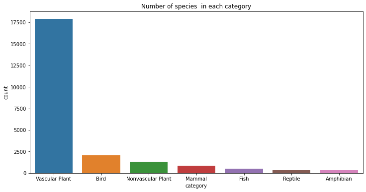

```python
plt.figure(figsize = ( 12, 6))
order = ['Vascular Plant', 'Bird', 'Nonvascular Plant', 'Mammal', 'Fish', 'Reptile', 'Amphibian']
sns.countplot(data = df, x = 'category', order= order)
plt.title('Number of species  in each category')
```

### let's see how many different species belong to one or another conservation status in each park

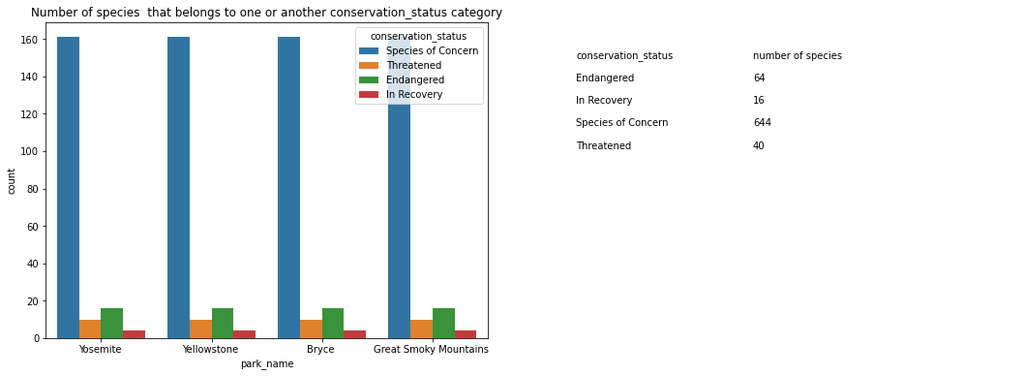

```python
plt.figure(figsize = (18,6))
plt.subplot(121)
sns.countplot(data = species_that_need_care, x = 'park_name',  hue = 'conservation_status')
plt.title('Number of species  that belongs to one or another conservation_status category')

df2 = species_that_need_care.groupby('conservation_status', ).count()
text1 = 'conservation_status'
for i in df2.index:
    text1 += '\n\n' + str(i)

text2 = 'number of species '
for i in df2.category:
    text2 += '\n\n' + str(i)

plt.subplot(122)
plt.axis('off')
plt.text(0.0, 0.6, text1)
plt.text(0.4, 0.6, text2)
```

We can see that all parks show the same result (notice graph shove number of species not a number of animals/observations in a category): most of the species belong to 'Species of concern ' category, 'in recovery' is the smallest category. Fact that all parks have the same bar plot means that **all species are present in each park**.

### Distribution of conservation_status by category

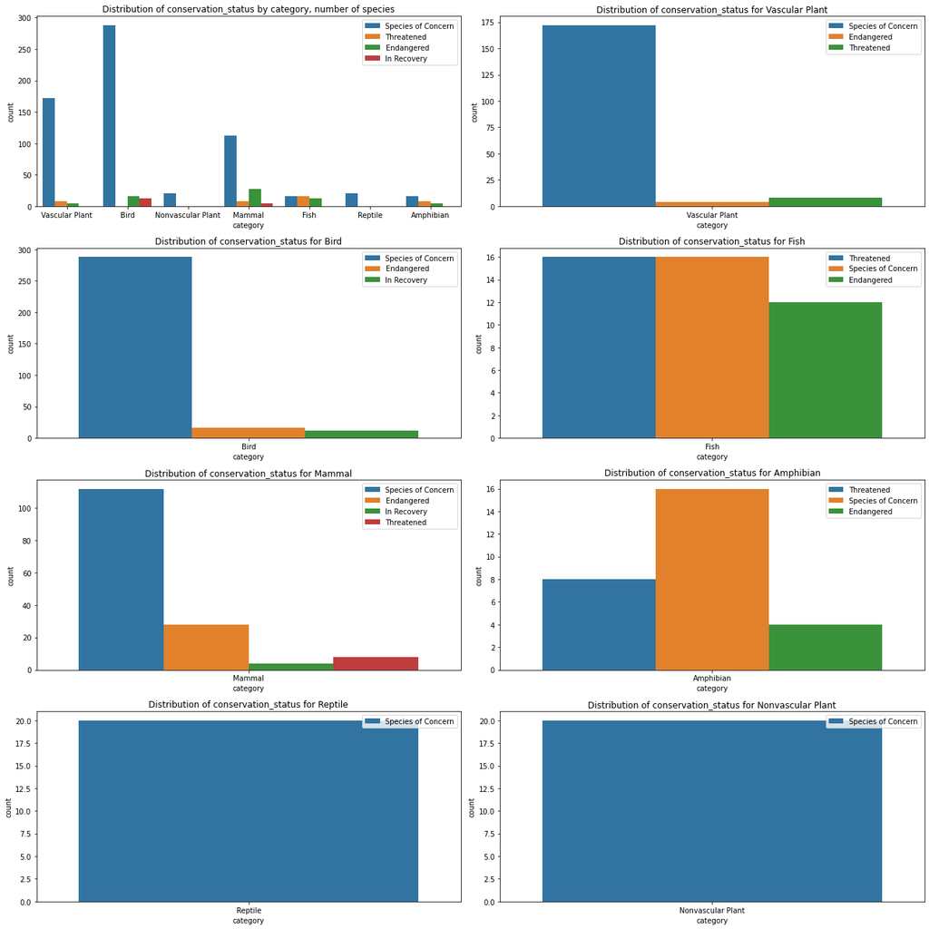

```python
plt.figure(figsize = (18,18))
plt.subplot(421)
sns.countplot(data = species_that_need_care, x = 'category',  hue = 'conservation_status', order= order)
plt.legend(loc = 1)
plt.title('Distribution of conservation_status by category, number of species')

category = species_that_need_care.category.unique().tolist()
for i in range(len(category)):
    plt.subplot(420 + i + 2)
    sns.countplot(data = species_that_need_care[species_that_need_care['category'] == category[i]], x = 'category',  hue = 'conservation_status')
    plt.legend(loc = 1)
    plt.title('Distribution of conservation_status for {}'.format(category[i]))
plt.tight_layout()
```

### Amount of animals and plants observed in each park

```
                   observations
category
Amphibian                  2752
Bird                      38600
Fish                       3753
Mammal                    16278
Nonvascular Plant          2705
Reptile                    2536
Vascular Plant            22849
```

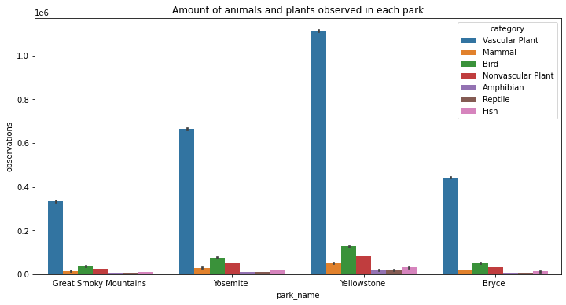

```python
print(species_that_need_care.groupby('category').sum())

plt.figure(figsize = (12,6))
sns.barplot(data = df, x = 'park_name', y = 'observations', estimator = sum , hue = 'category')
plt.title('Amount of animals and plants observed in each park')
```

### Observation vs species

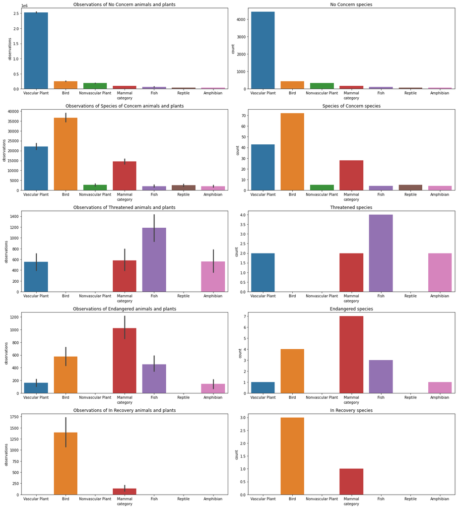

```python
plt.figure(figsize = (18,20))
conservation_status = df.conservation_status.unique().tolist()

for i in range(len(conservation_status)):

    plt.subplot(5,2,1 + 2*i)
    sns.barplot(data = df, x = df.category[df.conservation_status == conservation_status[i]], y = 'observations', estimator = sum, order= order )
    plt.title('Observations of {} animals and plants'.format(conservation_status[i]))

    plt.subplot(5,2,(2 + 2*i))
    sns.countplot(data = species, x = species.category[species.conservation_status == conservation_status[i]], order= order)
    plt.title(conservation_status[i] + ' species')
plt.tight_layout()
```

It worth mention about In the Recovery category only 3 species of birds and 1 species of mammals in recovery. All other categories have no recovery species.

### The most and the least observed species in the parks

```python
t = pd.DataFrame()
for park in df['park_name'].unique():
    park_df = df[df.park_name == park]
    max_observations = park_df.observations.max()
    t = pd.concat([t, park_df[park_df.observations == max_observations]])
print('\n', pd.DataFrame(t).reset_index(drop = True,).to_string())
```

```
                    scientific_name               park_name  observations        category conservation_status
0         Sonchus asper ssp. asper  Great Smoky Mountains            147  Vascular Plant          No Concern
1  Ivesia shockleyi var. shockleyi               Yosemite            223  Vascular Plant          No Concern
2           Lycopodium tristachyum            Yellowstone            321  Vascular Plant          No Concern
3             Valerianella radiata                  Bryce            176  Vascular Plant          No Concern
```

**Different species of vascular plant category are the most widely spread in all parks**.

```python
t = pd.DataFrame()
for park in df['park_name'].unique():
    park_df = df[df.park_name == park]
    max_observations = park_df.observations.min()
    t = pd.concat([t, park_df[park_df.observations == max_observations]])
print('\n', pd.DataFrame(t).reset_index(drop = True,).to_string())
```

```
       scientific_name               park_name  observations        category conservation_status
0  Collomia tinctoria  Great Smoky Mountains             10  Vascular Plant          No Concern
1     Noturus baileyi               Yosemite             31            Fish          Endangered
2      Grus americana            Yellowstone             57            Bird          Endangered
3     Corydalis aurea                  Bryce              9  Vascular Plant          No Concern
```

**Different parks have different rare species**. It is a bit strange that the rarest species in Bryce and Great Smoky Mountains have status 'No Concern'

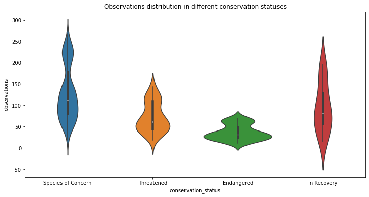

```python
plt.figure(figsize = (12,6))
sns.violinplot(data = species_that_need_care, x = 'conservation_status', y = 'observations')
plt.title('Observations distribution in different conservation statuses')
```

The fewer average animals/plants observed of some species the more dangerous the conservation status it gets.

## Appendix

Number of species that belongs to one or another conservation_status category including 'No Concern'

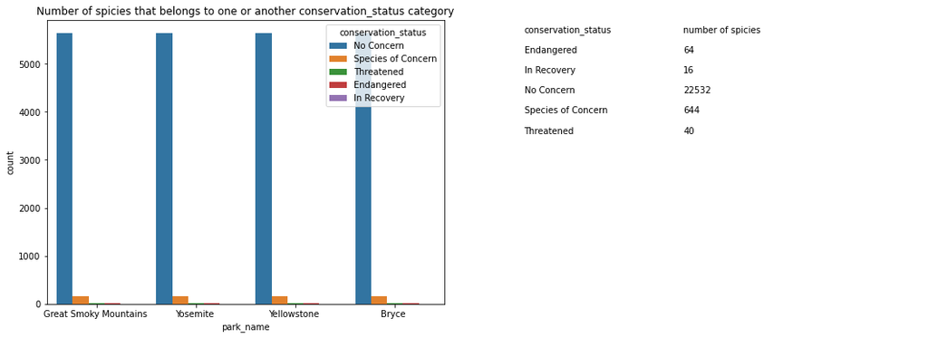

```python
plt.figure(figsize = (18,6))
plt.subplot(121)
sns.countplot(data = df, x = 'park_name',  hue = 'conservation_status')
plt.title('Number of spicies that belongs to one or another conservation_status category')

df2 = df.groupby('conservation_status', ).count()
text1 = 'conservation_status'
for i in df2.index:
    text1 += '\n\n' + str(i)

text2 = 'number of spicies'
for i in df2.category:
    text2 += '\n\n' + str(i)

plt.subplot(122)
plt.axis('off')
plt.text(0.0, 0.6, text1)
plt.text(0.4, 0.6, text2)
```